# Hyperstability

Ernesto Carrella

May 24, 2016

## Hyperstability

A common problem in fishery management is that catch data is not a good approximator of biomass. In particular “hyper-stable” fisheries are those where catches fall less rapidly than biomass, masking depletion until it’s too late. About 70% of fisheries are considered hyper-stable (see [Branch et al(2006)](http://www.nrcresearchpress.com/doi/abs/10.1139/f06-072#.V0Qni3U2uEI)).
Mathematically hyper-stability is defined as when we run the following regression:
$$\log(\text{CPUE}) = \alpha + \beta \log(\text{Biomass})$$
And $\beta < 1$.

It turns out that our very humble baseline scenario is hyper-stable. That is, this:

[video not shown]

if we let it run for 40 years produces the following CPUE and Biomass left:

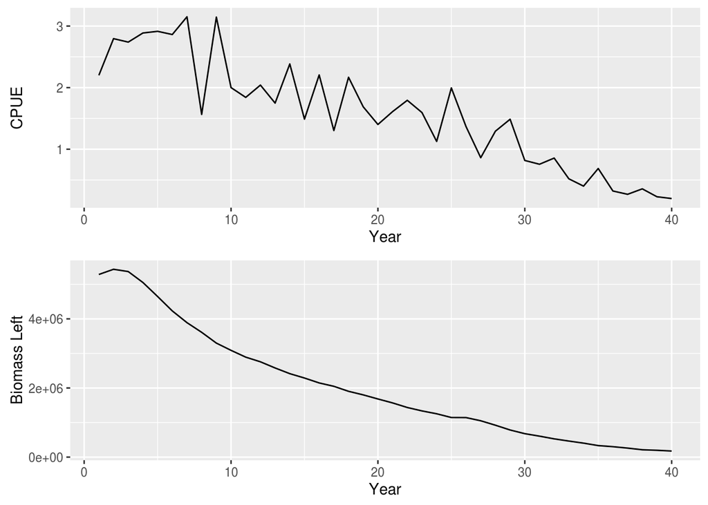

Which when fit gives us a $\beta = 0.71$. The hyper-stability is quite evident over the first 10 years where CPUE is stable or increasing while 2 fifths of the biomass are depleted.

This makes sense as hyper-stability is usually generated by human adapting to dwindling stocks by either fishing elsewhere or improving technology. In the baseline scenario there is no change in technology but agents simply fish further from port which mask some of the biomass depletion.

## Active test

Computational models are opaque: code is hard to read, parameters interact non-linearly and the input space is so large that most of it lays unexplored. We run the risk of focusing only on the inputs that “work” and ignore, or hide, the simulation runs that fail. To keep honest we should run ANTs (active non-linear tests). This involve letting the computer search for parameters that “break” the example. By knowing the parameters that do not work we delineate the limits of our model.

Fundamentally this is just another application for our Bayesian Optimizer. We manipulate 8 parameters: $\epsilon$ (exploration rate), $K$(carrying capacity of each sea-tile), $m$ (fish movement rate), “hold size”, “cell width”, “gas price”, “speed” and “catchability”. We instruct the optimizer to look for parameter combinations where $\beta > 1$ (hyperdepletion, that is catches fall faster than biomass). We constrain the optimizer to ignore cases where the fit is poor ($R^2<.2$) or where we see complete depletion $\text{Biomass}_{40} < 10000$ to avoid corner cases.

The optimizer finds the following setup:

| Parameter | Original | Hyperdepletion |
| --- | --- | --- |
| $\epsilon$ | 0.2 | 0.214070 |
| $K$ | 5000 | 17934.830391 |
| $m$ | 0.001 | 0.008191 |
| hold size | 100 | 308.252200 |
| cell width | 10 | 1.798591 |
| gas price | 0.01 | 0.240031 |
| speed | 5.0 | 5.907303 |
| catchability | 0.01 | 0.096322 |

Which generates a $\beta=1.2320$. The main difference between the hyperdepletion scenario and the original one is that capacity is much higher but so is the catchability of the boats. The end result is a very quick depletion event with little time for CPUE to hide much.

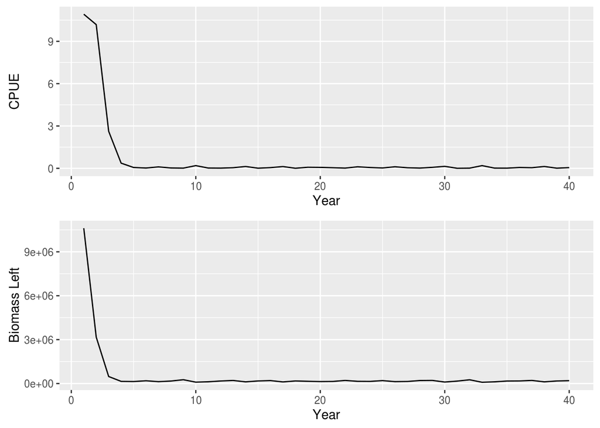